# Week 3

```r
library(tidyverse)
library(janitor)
```

## Testing for independence

### Case study: Delta vs Omicron

Marquez et al. (2022) looked into the Delta and Omicron variants of COVID-19 in terms of symptoms and rapid test results as well as the vaccination status. Data was collected at a walk-up community testing site in San Francisco.

We’re going to look at one specific example, but the authors considered many different combinations of symptoms, vaccination statuses and two different time periods.[^1]

```r
fever = tibble::tribble(
  ~symptom, ~status, ~count,
  "Fever", "Unvaccinated", 42,
  "No fever", "Unvaccinated", 116-42,
  "Fever", "Vaccinated, Boosted", 97,
  "No fever", "Vaccinated, Boosted", 432-97
)
# Table 3 Fever Boosted vs. Unvaccinated among positives
# matrix(c(42, 116-42, 97, 432-97), ncol = 2) |>
#   chisq.test(simulate.p.value = TRUE)
fever_tab = fever |>
  tidyr::pivot_wider(id_cols = symptom,
                     names_from = status,
                     values_from = count)
fever_tab |> gt::gt() |>
  gt::cols_label(symptom = "Symptom") |>
  gt::tab_spanner(label = "Vaccination status", columns = 2:3)
```

| Symptom | Vaccination status Unvaccinated | Vaccination status Vaccinated, Boosted |
| --- | --- | --- |
| Fever | 42 | 97 |
| No fever | 74 | 335 |

We can perform a test for independence between fever and vaccination status using the `chisq.test()` function to use the chi-square approximation or the `fisher.test()` function to perform Fisher’s exact test.

```r
fever_chisq = fever_tab |>
  dplyr::select(-1) |>
  chisq.test(correct = FALSE)
fever_chisq
```

```
    Pearson's Chi-squared test

data:  dplyr::select(fever_tab, -1)
X-squared = 9.1367, df = 1, p-value = 0.002505
```

```r
fever_fisher = fever_tab |>
  dplyr::select(-1) |>
  fisher.test()
fever_fisher
```

```
    Fisher's Exact Test for Count Data

data:  dplyr::select(fever_tab, -1)
p-value = 0.003752
alternative hypothesis: true odds ratio is not equal to 1
95 percent confidence interval:
 1.224724 3.107844
sample estimates:
odds ratio
  1.957543
```

Both approaches give very small p-values indicating that there is strong evidence against the null hypothesis of independence. The chi-square test yields p = 0.003 and Fisher’s exact test gives p = 0.004. Both approaches are valid (all expected cell counts are greater than 5, so the assumptions underlying the chi-square approximation are be well satisfied) and it’s comforting that they come to the same conclusion.

Figure 1 and Figure 2 visualise the data in two different ways using stacked bar charts. The take home message is similar from both. In Figure 1 we can see that patients who experienced fever were less likely to be vaccination than patients who did not experience fever, or equivalently, from Figure 2 unvaccinated individuals had higher rates of fever than vaccinated and boosted patients.

**Option A**

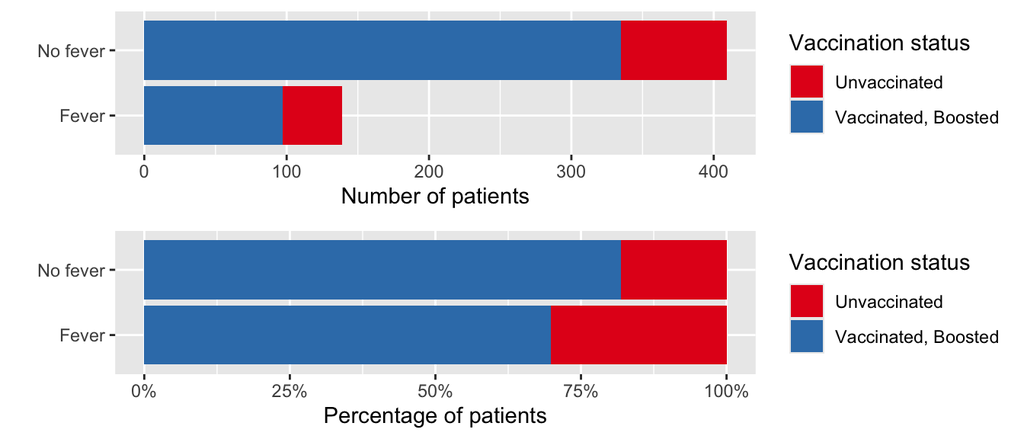

Figure 1: Raw counts and relative proportions of consumers who tested positive to COVID-19 during the Omicron period (Dec 1 2021 and Jan 30 2022) at a community testing site in San Francisco broken down by fever symptom and vaccination status.

```r
library(ggplot2)
p_base = fever |>
  ggplot() +
  aes(y = symptom, x = count, fill = status) +
  scale_fill_brewer(palette = "Set1") +
  labs(y = "",
       x = "Number of patients",
       fill = "Vaccination status")
p1 = p_base + geom_col()
p2 = p_base + geom_col(position = "fill") +
  scale_x_continuous(labels = scales::percent) +
  labs(x = "Percentage of patients")
cowplot::plot_grid(p1, p2, nrow = 2)
```

**Option B**

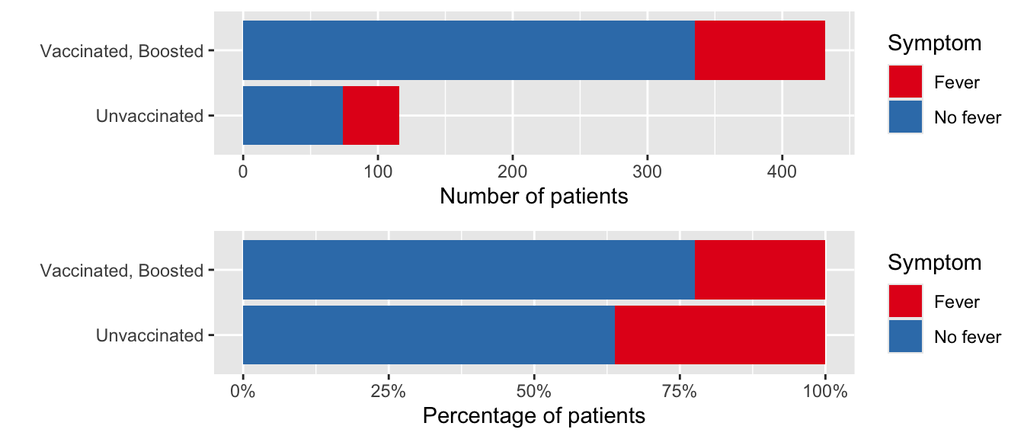

Figure 2: Raw counts and relative proportions of consumers who tested positive to COVID-19 during the Omicron period (Dec 1 2021 and Jan 30 2022) at a community testing site in San Francisco broken down by fever symptom and vaccination status.

```r
library(ggplot2)
p_base = fever |>
  ggplot() +
  aes(y = status, x = count, fill = symptom) +
  scale_fill_brewer(palette = "Set1") +
  labs(y = "",
       x = "Number of patients",
       fill = "Symptom")
p1 = p_base + geom_col()
p2 = p_base + geom_col(position = "fill") +
  scale_x_continuous(labels = scales::percent) +
  labs(x = "Percentage of patients")
cowplot::plot_grid(p1, p2, nrow = 2)
```

### Case study: Gamer spending

The 2022 Deloitte Insights digital media trends survey[^2] reported on a survey of 373 US gamers who attended a live event inside a video game. Participants were asked about their age and whether they made a purchase because of the live event. Overall, 82% of responses made a purchase (either physical merchandise or a digital good). The number of respondees are broken down by purchase outcome and generation in the table below.

Is there any evidence to suggest that there is a relationship between purchasing intention and generation label?

```r
gamers = tibble::tribble(
  ~purchase, ~generation, ~count,
  "Yes", "Generation Z", 60,
  "No", "Generation Z", 34,
  "Yes", "Millennials", 203,
  "No", "Millennials", 28,
  "Yes", "Generation X", 44,
  "No", "Generation X", 4
) |>
  dplyr::mutate(
    generation = factor(generation,
                        levels = c("Generation Z",
                                   "Millennials",
                                   "Generation X")
    )
  )

gamer_tab = gamers |>
  tidyr::pivot_wider(id_cols = purchase,
                     names_from = generation,
                     values_from = count)
library(gt)
gamer_tab |> gt() |>
  cols_label(
    purchase = html("Purchase<br>outcome")
  )
```

| Purchase outcome | Generation Z | Millennials | Generation X |
| --- | --- | --- | --- |
| Yes | 60 | 203 | 44 |
| No | 34 | 28 | 4 |

We can use the `chisq.test()` function to perform a test for independence between the generation a person belongs to and their purchasing outcome.

```r
gamer_chisq = gamer_tab |>
  dplyr::select(-purchase) |>
  chisq.test()
# check that all the expected cell counts are
# reasonably large (e.g. larger than 5)
# gamer_chisq$expected
gamer_chisq
```

```
    Pearson's Chi-squared test

data:  dplyr::select(gamer_tab, -purchase)
X-squared = 29.848, df = 2, p-value = 3.301e-07
```

There is strong evidence, p < .001, to suggest that purchase outcome is not independent of generation. Hence, the age of the attendee is related to their propensity to purchase something. In Figure 3 we can see that Generation Z are much less likely to purchase merchandise than Millennial or Generation X.

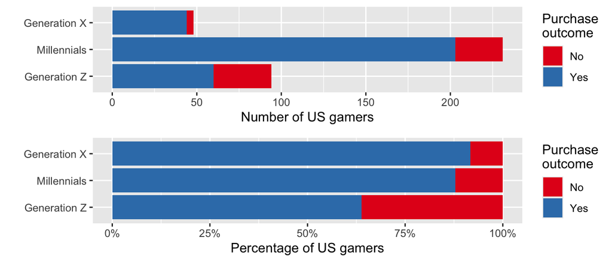

Figure 3: Raw counts and relative proportions of consumers who attended an online live gaming event who made a purchase or not broken down by generation.

```r
library(ggplot2)
p_base = gamers |>
  ggplot() +
  aes(y = generation, x = count, fill = purchase) +
  scale_fill_brewer(palette = "Set1")
p1 = p_base + geom_col() +
  labs(y = "",
       x = "Number of US gamers",
       fill = "Purchase\noutcome")
p2 = p_base + geom_col(position = "fill") +
  scale_x_continuous(labels = scales::percent) +
  labs(y = "",
       x = "Percentage of US gamers",
       fill = "Purchase\noutcome")
cowplot::plot_grid(p1, p2, nrow = 2)
```

## Testing for homogeneity

Read in the COVID treatment data:

```r
# covid_data = readxl::read_excel("extra/covid_treatment_outcomes.xlsx") |>
#   janitor::clean_names()
raw_dat = read_csv("https://raw.githubusercontent.com/DATA2002/data/master/covidplasma.csv")
dplyr::glimpse(raw_dat)
```

```
Rows: 195
Columns: 3
$ subject   <dbl> 1, 2, 3, 4, 5, 6, 7, 8, 9, 10, 11, 12, 13, 14, 15, 16, 17, 1…
$ treatment <chr> "Plasma", "Plasma", "Plasma", "Plasma", "Plasma", "Plasma", …
$ outcome   <chr> "Died", "Died", "Died", "Died", "Died", "Discharged", "Disch…
```

```r
dat = raw_dat %>%
  mutate(subject = as.character(subject)) |>
  filter(outcome != "Censored") %>%
  mutate(treatment = factor(treatment, levels = c("Plasma", "No plasma")),
         outcome = factor(outcome, levels = c("Died", "Discharged")))
```

```r
covid_tab = table(dat$treatment, dat$outcome)
covid_tab
```

```
            Died Discharged
  Plasma       5         28
  No plasma   38        104
```

```r
chisq.test(covid_tab, correct = FALSE)
```

```
    Pearson's Chi-squared test

data:  covid_tab
X-squared = 1.9471, df = 1, p-value = 0.1629
```

```r
dat |> janitor::tabyl(treatment, outcome) |> chisq.test()
```

```
    Pearson's Chi-squared test with Yates' continuity correction

data:  janitor::tabyl(dat, treatment, outcome)
X-squared = 1.3711, df = 1, p-value = 0.2416
```

```r
y = c(62, 47, 29, 46, 9, 7)
n = sum(y)
c = 3
r = 2
tab = matrix(y, nrow = r, ncol = c)
tab
```

```
     [,1] [,2] [,3]
[1,]   62   29    9
[2,]   47   46    7
```

```r
# default is to fill by column
colnames(tab) = c("Approve",
                  "Not approve",
                  "No comment")
rownames(tab) = c("Labor", "Liberal")
tab
```

```
        Approve Not approve No comment
Labor        62          29          9
Liberal      47          46          7
```

## Testing in small samples

### Fisher’s test

```r
truth = c("milk","tea","tea","milk","tea","tea","milk","milk")
predicted = c("milk","tea","tea","milk","tea","tea","milk","milk")
tea_mat = table(truth, predicted)
tea_mat
```

```
      predicted
truth  milk tea
  milk    4   0
  tea     0   4
```

```r
chisq.test(tea_mat, correct = FALSE)
```

```
    Pearson's Chi-squared test

data:  tea_mat
X-squared = 8, df = 1, p-value = 0.004678
```

```r
fisher.test(tea_mat)
```

```
    Fisher's Exact Test for Count Data

data:  tea_mat
p-value = 0.02857
alternative hypothesis: true odds ratio is not equal to 1
95 percent confidence interval:
 1.339059      Inf
sample estimates:
odds ratio
       Inf
```

```r
fisher.test(tea_mat, alternative = "greater")
```

```
    Fisher's Exact Test for Count Data

data:  tea_mat
p-value = 0.01429
alternative hypothesis: true odds ratio is greater than 1
95 percent confidence interval:
 2.003768      Inf
sample estimates:
odds ratio
       Inf
```

### Cancer surgery

```r
y_mat = matrix(c(21, 15, 2, 3), ncol = 2)
colnames(y_mat) = c("Controlled", "Not controlled")
rownames(y_mat) = c("Surgery", "Radiation therapy")
y_mat
```

```
                  Controlled Not controlled
Surgery                   21              2
Radiation therapy         15              3
```

```r
fisher.test(y_mat, alternative = "greater")
```

```
    Fisher's Exact Test for Count Data

data:  y_mat
p-value = 0.3808
alternative hypothesis: true odds ratio is greater than 1
95 percent confidence interval:
 0.2864828       Inf
sample estimates:
odds ratio
  2.061731
```

### Yates’ correction

```r
chisq.test(tea_mat,correct=FALSE)
```

```
    Pearson's Chi-squared test

data:  tea_mat
X-squared = 8, df = 1, p-value = 0.004678
```

```r
chisq.test(tea_mat,correct=TRUE)
```

```
    Pearson's Chi-squared test with Yates' continuity correction

data:  tea_mat
X-squared = 4.5, df = 1, p-value = 0.03389
```

```r
fisher.test(tea_mat)
```

```
    Fisher's Exact Test for Count Data

data:  tea_mat
p-value = 0.02857
alternative hypothesis: true odds ratio is not equal to 1
95 percent confidence interval:
 1.339059      Inf
sample estimates:
odds ratio
       Inf
```

If we wanted to do this manually:

```r
(tea_mat = table(truth, predicted))
```

```
      predicted
truth  milk tea
  milk    4   0
  tea     0   4
```

```r
r = c = 2
yr=apply(tea_mat,1,sum) # Or try rowSums()
yc=apply(tea_mat,2,sum) # Or try colSums()
yr.mat=matrix(yr,r,c,byrow = FALSE)
yc.mat=matrix(yc,r,c,byrow = TRUE)
# etea_mat = yr%*%t(yc)/n
(etea_mat=yr.mat*yc.mat/sum(tea_mat))
```

```
     [,1] [,2]
[1,]    2    2
[2,]    2    2
```

```r
(res.yates = (abs(tea_mat-etea_mat)-0.5)^2/etea_mat)
```

```
      predicted
truth   milk   tea
  milk 1.125 1.125
  tea  1.125 1.125
```

```r
(t0 = sum(res.yates))
```

```
[1] 4.5
```

```r
#Calculate p-values
pchisq(t0, 1, lower.tail = FALSE)
```

```
[1] 0.03389485
```

### Simulation

```r
galton.dat <- matrix(c(5, 4, 1, 12, 42, 14, 2, 15, 10), 3, 3)
rownames(galton.dat) = c("Arches-B", "Loops-B", "Whorls-B")
colnames(galton.dat) = c("Arches-A", "Loops-A", "Whorls-A")
galton.dat
```

```
         Arches-A Loops-A Whorls-A
Arches-B        5      12        2
Loops-B         4      42       15
Whorls-B        1      14       10
```

```r
chisq.test(galton.dat)$expected
```

```
         Arches-A  Loops-A  Whorls-A
Arches-B 1.809524 12.30476  4.885714
Loops-B  5.809524 39.50476 15.685714
Whorls-B 2.380952 16.19048  6.428571
```

```r
row_totals = rowSums(galton.dat)
col_totals = colSums(galton.dat)
B = 10000
set.seed(123)
x_list = r2dtable(n = B,
                  r = row_totals,
                  c = col_totals)
x_list[[1]]
```

```
     [,1] [,2] [,3]
[1,]    2   10    7
[2,]    7   43   11
[3,]    1   15    9
```

```r
chisq.test(x_list[[1]])
```

```
    Pearson's Chi-squared test

data:  x_list[[1]]
X-squared = 5.2367, df = 4, p-value = 0.2639
```

```r
rnd.chisq = numeric(B)
for (i in 1:B){
  rnd.chisq[i] = suppressWarnings(chisq.test(x_list[[i]])$statistic)
}
sum(rnd.chisq >= 11.1699)/B
```

```
[1] 0.022
```

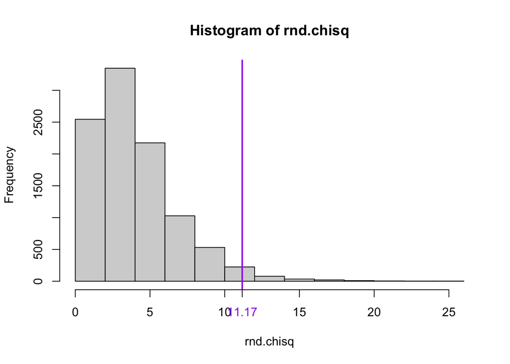

```r
hist(rnd.chisq)
abline(v = 11.17, col = "purple", lwd = 2)
axis(1, 11.17, col.axis = "purple")
```

```r
chisq.test(galton.dat, simulate.p.value = TRUE)
```

```
    Pearson's Chi-squared test with simulated p-value (based on 2000
    replicates)

data:  galton.dat
X-squared = 11.17, df = NA, p-value = 0.01999
```

```r
chisq.test(galton.dat, simulate.p.value = TRUE, B = 10000)
```

```
    Pearson's Chi-squared test with simulated p-value (based on 10000
    replicates)

data:  galton.dat
X-squared = 11.17, df = NA, p-value = 0.0232
```

## Power!

Say we’re trying to test the null hypothesis that births are uniformly distributed across the 4 seasons.

We can generate some data and perform the test:

```r
seasons = c("Summer", "Autumn", "Winter", "Spring")
x = sample(seasons,
           prob = c(0.25,0.25,0.25,0.25),
           size = 100,
           replace = TRUE)
xtab = table(x)
chisq.test(xtab)
```

```
    Chi-squared test for given probabilities

data:  xtab
X-squared = 1.04, df = 3, p-value = 0.7916
```

What if we generate data where the null hypothesis is false? Do we typically reject the null hypothesis? What about if you increase the sample size?

```r
x = sample(seasons,
           prob = c(0.2,0.3,0.3,0.2),
           size = 100,
           replace = TRUE)
xtab = table(x)
chisq.test(xtab)
```

```
    Chi-squared test for given probabilities

data:  xtab
X-squared = 2.96, df = 3, p-value = 0.3978
```

## References

Marquez, Carina, Andrew D. Kerkhoff, John Schrom, Susana Rojas, Douglas Black, Anthea Mitchell, Chung-Yu Wang, et al. 2022. “COVID-19 Symptoms and Duration of Rapid Antigen Test Positivity at a Community Testing and Surveillance Site During Pre-Delta, Delta, and Omicron BA.1 Periods.” *JAMA Network Open* 5 (10): e2235844. https://doi.org/10.1001/jamanetworkopen.2022.35844.

## Footnotes

[^1]: There’s a tweet summary of the paper [here](https://twitter.com/DataDrivenMD/status/1528825593009041408?s=20&t=KrSBkB-VH3XYUe9n1MDmEQ).
[^2]: Source: [2022 Digital media trends, 16th edition: Toward the metaverse](https://www2.deloitte.com/us/en/insights/industry/technology/digital-media-trends-consumption-habits-survey/summary.html), Accessed: 23 July 2022.